# matplotlib.figure.Figure.text

**Figure.text(*x*, *y*, *s*, *fontdict=None*, **kwargs)[[source]](https://github.com/matplotlib/matplotlib/blob/v3.10.8/lib/matplotlib/figure.py#L1143-L1191)**

Add text to figure.

**Parameters:**

**x, y**float**

The position to place the text. By default, this is in figure coordinates, floats in [0, 1]. The coordinate system can be changed using the *transform* keyword.

**s**str**

The text string.

**fontdict**dict, optional**

A dictionary to override the default text properties. If not given, the defaults are determined by `rcParams["font.*"]`. Properties passed as *kwargs* override the corresponding ones given in *fontdict*.

**Returns:**

**`Text`**

**Other Parameters:**

**kwargs`Text` properties**

Other miscellaneous text parameters.

| Property | Description |
| --- | --- |
| `agg_filter` | a filter function, which takes a (m, n, 3) float array and a dpi value, and returns a (m, n, 3) array and two offsets from the bottom left corner of the image |
| `alpha` | float or None |
| `animated` | bool |
| `antialiased` | bool |
| `backgroundcolor` | [color](https://matplotlib.org/stable/users/explain/colors/colors.html#colors-def) |
| `bbox` | dict with properties for `patches.FancyBboxPatch` |
| `clip_box` | unknown |
| `clip_on` | unknown |
| `clip_path` | unknown |
| `color` or `c` | [color](https://matplotlib.org/stable/users/explain/colors/colors.html#colors-def) |
| `figure` | `Figure` or `SubFigure` |
| `fontfamily` or `family` or `fontname` | {FONTNAME, 'serif', 'sans-serif', 'cursive', 'fantasy', 'monospace'} |
| `fontproperties` or `font` or `font_properties` | `font_manager.FontProperties` or [`str`](https://docs.python.org/3/library/stdtypes.html#str) or [`pathlib.Path`](https://docs.python.org/3/library/pathlib.html#pathlib.Path) |
| `fontsize` or `size` | float or {'xx-small', 'x-small', 'small', 'medium', 'large', 'x-large', 'xx-large'} |
| `fontstretch` or `stretch` | {a numeric value in range 0-1000, 'ultra-condensed', 'extra-condensed', 'condensed', 'semi-condensed', 'normal', 'semi-expanded', 'expanded', 'extra-expanded', 'ultra-expanded'} |
| `fontstyle` or `style` | {'normal', 'italic', 'oblique'} |
| `fontvariant` or `variant` | {'normal', 'small-caps'} |
| `fontweight` or `weight` | {a numeric value in range 0-1000, 'ultralight', 'light', 'normal', 'regular', 'book', 'medium', 'roman', 'semibold', 'demibold', 'demi', 'bold', 'heavy', 'extra bold', 'black'} |
| `gid` | str |
| `horizontalalignment` or `ha` | {'left', 'center', 'right'} |
| `in_layout` | bool |
| `label` | object |
| `linespacing` | float (multiple of font size) |
| `math_fontfamily` | str |
| `mouseover` | bool |
| `multialignment` or `ma` | {'left', 'right', 'center'} |
| `parse_math` | bool |
| `path_effects` | list of `AbstractPathEffect` |
| `picker` | None or bool or float or callable |
| `position` | (float, float) |
| `rasterized` | bool |
| `rotation` | float or {'vertical', 'horizontal'} |
| `rotation_mode` | {None, 'default', 'anchor'} |
| `sketch_params` | (scale: float, length: float, randomness: float) |
| `snap` | bool or None |
| `text` | object |
| `transform` | `Transform` |
| `transform_rotates_text` | bool |
| `url` | str |
| `usetex` | bool, default: `rcParams["text.usetex"]` (default: `False`) |
| `verticalalignment` or `va` | {'baseline', 'bottom', 'center', 'center_baseline', 'top'} |
| `visible` | bool |
| `wrap` | bool |
| `x` | float |
| `y` | float |
| `zorder` | float |

See also

**`Axes.text`**

**`pyplot.text`**

## Examples using `matplotlib.figure.Figure.text`

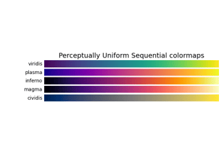

[Colormap reference](https://matplotlib.org/stable/gallery/color/colormap_reference.html)

Colormap reference

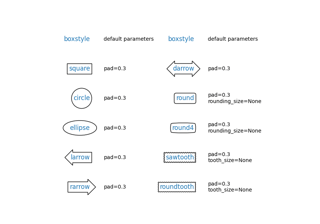

[Drawing fancy boxes](https://matplotlib.org/stable/gallery/shapes_and_collections/fancybox_demo.html)

Drawing fancy boxes

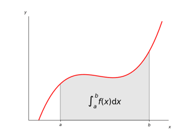

[Integral as the area under a curve](https://matplotlib.org/stable/gallery/showcase/integral.html)

Integral as the area under a curve

[figure not shown]

[XKCD](https://matplotlib.org/stable/gallery/showcase/xkcd.html)

XKCD

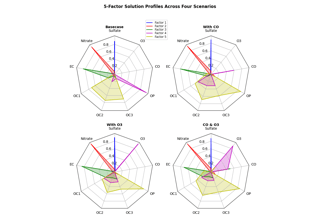

[Radar chart (aka spider or star chart)](https://matplotlib.org/stable/gallery/specialty_plots/radar_chart.html)

Radar chart (aka spider or star chart)

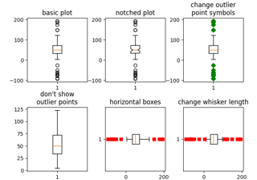

[Boxplots](https://matplotlib.org/stable/gallery/statistics/boxplot_demo.html)

Boxplots

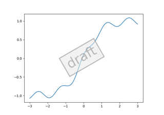

[Custom Figure subclasses](https://matplotlib.org/stable/gallery/subplots_axes_and_figures/custom_figure_class.html)

Custom Figure subclasses

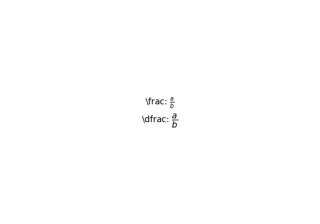

[The difference between \dfrac and \frac](https://matplotlib.org/stable/gallery/text_labels_and_annotations/dfrac_demo.html)

The difference between \dfrac and \frac

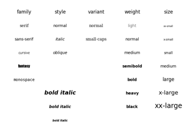

[Fonts demo (object-oriented style)](https://matplotlib.org/stable/gallery/text_labels_and_annotations/fonts_demo.html)

Fonts demo (object-oriented style)

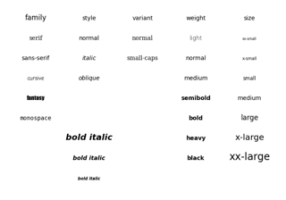

[Fonts demo (keyword arguments)](https://matplotlib.org/stable/gallery/text_labels_and_annotations/fonts_demo_kw.html)

Fonts demo (keyword arguments)

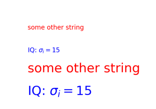

[Convert texts to images](https://matplotlib.org/stable/gallery/text_labels_and_annotations/mathtext_asarray.html)

Convert texts to images

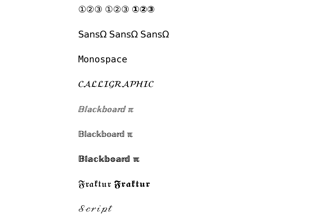

[STIX Fonts](https://matplotlib.org/stable/gallery/text_labels_and_annotations/stix_fonts_demo.html)

STIX Fonts

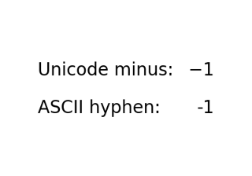

[Unicode minus](https://matplotlib.org/stable/gallery/text_labels_and_annotations/unicode_minus.html)

Unicode minus

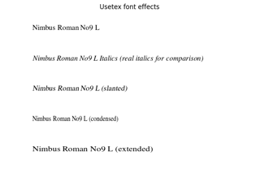

[Usetex font effects](https://matplotlib.org/stable/gallery/text_labels_and_annotations/usetex_fonteffects.html)

Usetex font effects

[figure not shown]

[Text watermark](https://matplotlib.org/stable/gallery/text_labels_and_annotations/watermark_text.html)

Text watermark

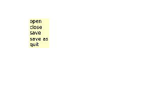

[Menu](https://matplotlib.org/stable/gallery/widgets/menu.html)

Menu

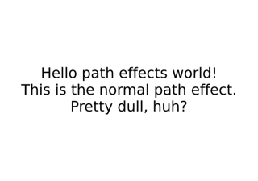

[Path effects guide](https://matplotlib.org/stable/users/explain/artists/patheffects_guide.html)

Path effects guide

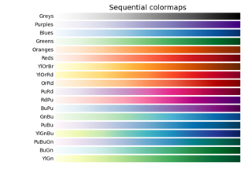

[Choosing Colormaps in Matplotlib](https://matplotlib.org/stable/users/explain/colors/colormaps.html)

Choosing Colormaps in Matplotlib

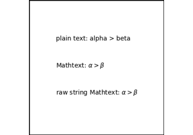

[Writing mathematical expressions](https://matplotlib.org/stable/users/explain/text/mathtext.html)

Writing mathematical expressions